# Transcript level differential expression with Sleuth

Sleuth is one of a new class of tools for doing differential expression. The papers that Fabio linked to us mostly looked at inclusion-exclusion events by looking at reads passing over splice junctions. This type of approach throws away a lot of information.

There is some ambiguity when trying to assign an alignment to a particular transcript which introduces technical variation. The idea behind sleuth is to try to separate out the technical variation from the biological variation by bootstrap sampling to estimate the technical variation and removing it from the overall variation.

```r
> library(dplyr)
> library(sleuth)
> load("counts.RData")
> sample_dirs = file.path("..", "..", rownames(summarydata))
> sf_dirs = file.path(sample_dirs, "sailfish", "quant")
> names(sf_dirs) = rownames(summarydata)
> sfdata = summarydata[, "genotype", drop = FALSE]
> sfdata$sample = rownames(sfdata)
> sfdata$path = sf_dirs
> design = ~genotype
```

```r
> mart <- biomaRt::useMart(biomart = "ensembl", dataset = "hsapiens_gene_ensembl")
> t2g <- biomaRt::getBM(attributes = c("ensembl_transcript_id", "ensembl_gene_id",
+     "external_gene_name", "gene_biotype", "transcript_biotype"), mart = mart)
> t2g <- dplyr::rename(t2g, target_id = ensembl_transcript_id, ens_gene = ensembl_gene_id,
+     ext_gene = external_gene_name)
> so = sleuth_prep(sfdata, design, target_mapping = t2g) %>% sleuth_fit()
> so = sleuth_wt(so, "genotypeprpf8")
> so = sleuth_wt(so, "genotypeprpf38")
> prpf8_tab = sleuth_results(so, "genotypeprpf8", show_all = TRUE)
> prpf38_tab = sleuth_results(so, "genotypeprpf38", show_all = TRUE)
```

We considered 196501 transcripts in total. We find 29680 transcripts differentially expressed in `PRPF8` and 16955 transcripts differentially expressed in `PRPF38`.

## MCL1

MCL1 has three isoforms ENST00000464132, ENST00000369026, ENST00000307940. Here we plot the boxplots of the bootstrap estimates for the counts for each transcript, colored by genotype of the samples.

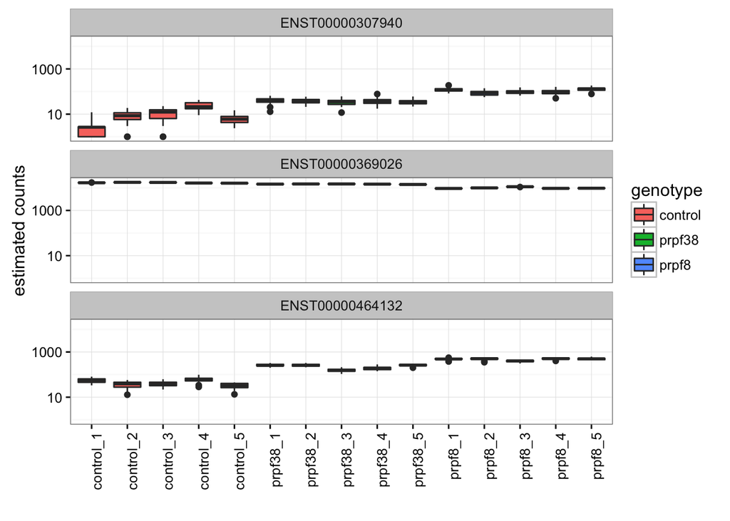

```r
> df = get_bootstraps(so, "ENST00000464132")
> df = rbind(df, get_bootstraps(so, "ENST00000369026"))
> df = rbind(df, get_bootstraps(so, "ENST00000307940"))
> ggplot(df, aes(sample, est_counts + 1, fill = genotype)) + geom_boxplot() +
+     facet_wrap(~target_id, ncol = 1) + theme_bw() + scale_y_log10() + theme(axis.text.x = element_text(angle = 90,
+     hjust = 1)) + ylab("estimated counts") + xlab("")
```

It looks like we can see the splice difference in `PRPF8` compared to `control` here. Specifically, an upregulation of `ENST00000307940` and `ENST00000464132`. All three transcripts are significantly different from `control` in both the `PRPF8` and `PRPF38` samples.

Below we can see that `ENST00000369026` which is down in `PRPF8` and `PRPF38` is the longest isoform– the other two transcripts are missing the 3’ UTR of the transcript. There is some evidence then that loss of `PRPF8` and `PRPF38` leads to the loss of the 3’ UTR of `MCL1`.

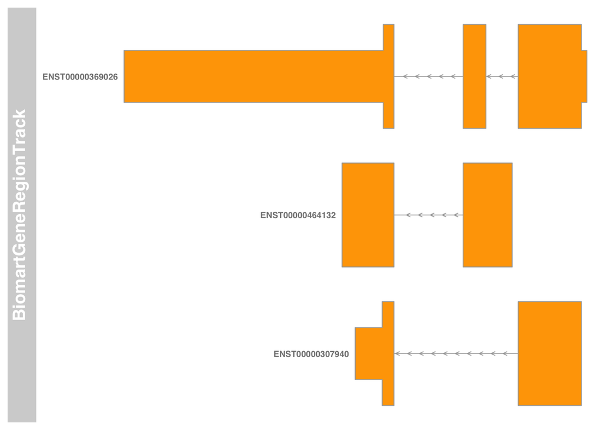

```r
> library("Gviz")
> library("GenomicRanges")
> library("biomaRt")
> library("BiocGenerics")
> bmt = BiomartGeneRegionTrack(genome = "hg19", symbol = "MCL1")
> plotTracks(bmt, transcriptAnnotation = "transcript")
```

Looking at the alignments for MCL1, we can see that there is a drop in the 3’ UTR for PRPF8.

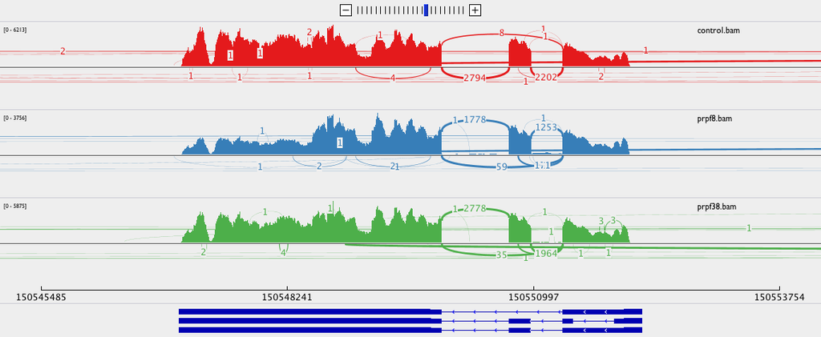

MCL1-sashimi

The 5’-3’ bias, a measure of degradation, doesn’t look much different between the samples, so that doesn’t explain the difference.

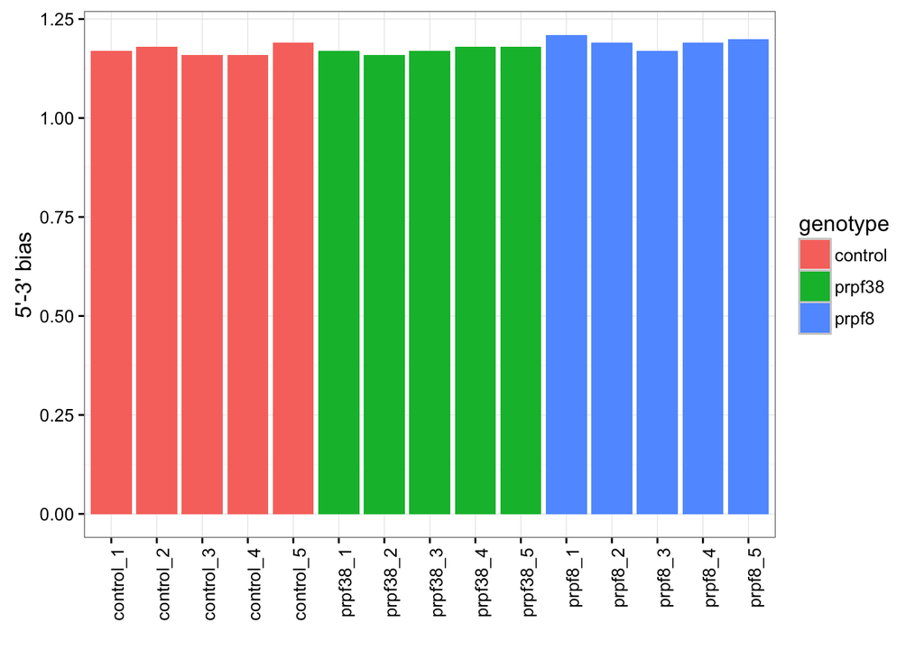

```r
> library(ggplot2)
> ggplot(summarydata, aes(Name, X5.3.bias, fill = genotype)) + geom_bar(stat = "identity",
+     position = "dodge") + theme_bw() + ylab("5'-3' bias") + xlab("") + theme(axis.text.x = element_text(angle = 90,
+     hjust = 1))
```

```r
> mcl1 = subset(prpf8_tab, ext_gene == "MCL1")
> mcl1_considered = mcl1[complete.cases(mcl1), ]$target_id
> mcl1_prpf8 = subset(prpf8_tab, ext_gene == "MCL1" & qval < 0.05 & complete.cases(prpf8_tab))
> mcl1_prpf38 = subset(prpf38_tab, ext_gene == "MCL1" & qval < 0.05 & complete.cases(prpf38_tab))
```

### PRPF8 compared to control

```r
> knitr::kable(mcl1_prpf8)
```

|  | target_id | pval | qval | b | se_b | mean_obs | var_obs | tech_var | sigma_sq | smooth_sigma_sq | final_sigma_sq | ens_gene | ext_gene | gene_biotype | transcript_biotype |
| --- | --- | --- | --- | --- | --- | --- | --- | --- | --- | --- | --- | --- | --- | --- | --- |
| 1604 | ENST00000464132 | 0 | 0 | 2.3445060 | 0.1464393 | 5.132820 | 1.0690173 | 0.0396757 | 0.0115420 | 0.0139355 | 0.0139355 | ENSG00000143384 | MCL1 | protein_coding | processed_transcript |
| 1616 | ENST00000369026 | 0 | 0 | -0.5263093 | 0.0330074 | 9.508660 | 0.0549156 | 0.0000995 | 0.0021163 | 0.0026242 | 0.0026242 | ENSG00000143384 | MCL1 | protein_coding | protein_coding |
| 8225 | ENST00000307940 | 0 | 0 | 2.6492689 | 0.3807459 | 3.436454 | 1.4956027 | 0.2517913 | 0.0058972 | 0.1106273 | 0.1106273 | ENSG00000143384 | MCL1 | protein_coding | protein_coding |

### PRPF38 compared to control

```r
> knitr::kable(mcl1_prpf38)
```

|  | target_id | pval | qval | b | se_b | mean_obs | var_obs | tech_var | sigma_sq | smooth_sigma_sq | final_sigma_sq | ens_gene | ext_gene | gene_biotype | transcript_biotype |
| --- | --- | --- | --- | --- | --- | --- | --- | --- | --- | --- | --- | --- | --- | --- | --- |
| 1212 | ENST00000464132 | 0.00e+00 | 0.0000000 | 1.5999886 | 0.1464393 | 5.132820 | 1.0690173 | 0.0396757 | 0.0115420 | 0.0139355 | 0.0139355 | ENSG00000143384 | MCL1 | protein_coding | processed_transcript |
| 8258 | ENST00000369026 | 1.93e-05 | 0.0001689 | -0.1410187 | 0.0330074 | 9.508660 | 0.0549156 | 0.0000995 | 0.0021163 | 0.0026242 | 0.0026242 | ENSG00000143384 | MCL1 | protein_coding | protein_coding |
| 8273 | ENST00000307940 | 1.99e-05 | 0.0001731 | 1.6244402 | 0.3807459 | 3.436454 | 1.4956027 | 0.2517913 | 0.0058972 | 0.1106273 | 0.1106273 | ENSG00000143384 | MCL1 | protein_coding | protein_coding |

## PRPF38

PRPF38 is knocked down but not out.

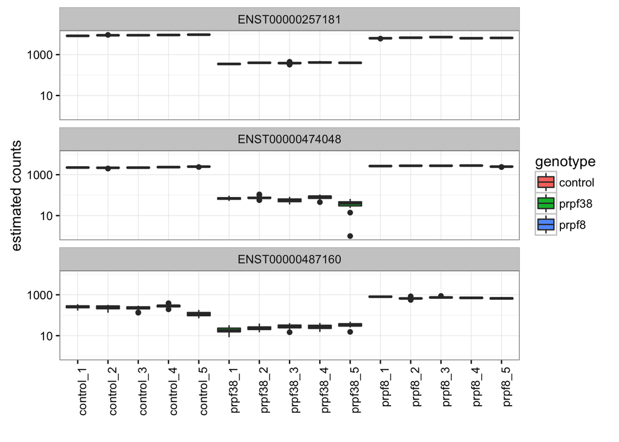

```r
> prpf38_considered = subset(prpf8_tab, ext_gene == "PRPF38A")$target_id
> df = Map(function(x) {
+     get_bootstraps(so, x)
+ }, prpf38_considered)
> df = do.call(rbind, df)
> ggplot(df, aes(sample, est_counts + 1, fill = genotype)) + geom_boxplot() +
+     facet_wrap(~target_id, ncol = 1) + theme_bw() + scale_y_log10() + theme(axis.text.x = element_text(angle = 90,
+     hjust = 1)) + ylab("estimated counts") + xlab("")
```

## PRPF8

The PRPF8 knockout seems less complete, there are only two isoforms that are knocked down in the PRPF8 samples:

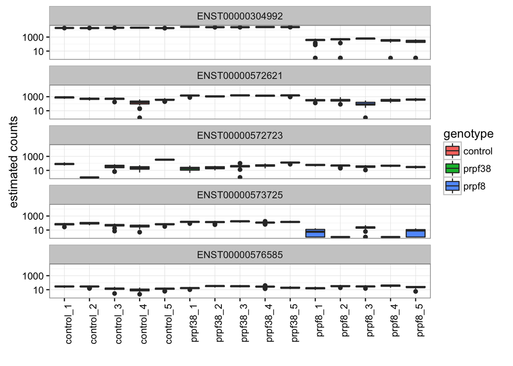

```r
> prpf8_considered = subset(prpf8_tab, ext_gene == "PRPF8" & !is.na(pval))$target_id
> df = Map(function(x) {
+     get_bootstraps(so, x)
+ }, prpf8_considered)
> df = do.call(rbind, df)
> ggplot(df, aes(sample, est_counts + 1, fill = genotype)) + geom_boxplot() +
+     facet_wrap(~target_id, ncol = 1) + theme_bw() + scale_y_log10() + theme(axis.text.x = element_text(angle = 90,
+     hjust = 1)) + ylab("estimated counts") + xlab("")
```

## RIOK3

There are many more isoforms for RIOK3:

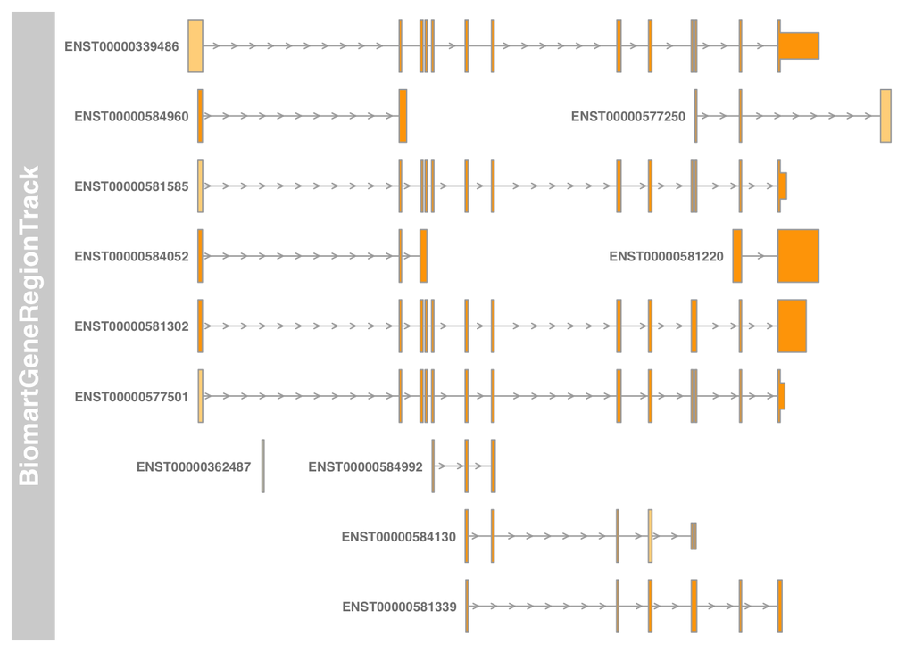

```r
> bmt = BiomartGeneRegionTrack(genome = "hg19", symbol = "RIOK3")
> plotTracks(bmt, transcriptAnnotation = "transcript")
```

```r
> riok3 = subset(prpf8_tab, ext_gene == "RIOK3")
> riok3_considered = riok3[complete.cases(riok3), ]$target_id
> riok3_prpf8 = subset(prpf8_tab, ext_gene == "RIOK3" & qval < 0.05 & complete.cases(prpf8_tab))
> riok3_prpf38 = subset(prpf38_tab, ext_gene == "RIOK3" & qval < 0.05 & complete.cases(prpf38_tab))
```

### PRPF8 compared to control

```r
> knitr::kable(riok3_prpf8)
```

|  | target_id | pval | qval | b | se_b | mean_obs | var_obs | tech_var | sigma_sq | smooth_sigma_sq | final_sigma_sq | ens_gene | ext_gene | gene_biotype | transcript_biotype |
| --- | --- | --- | --- | --- | --- | --- | --- | --- | --- | --- | --- | --- | --- | --- | --- |
| 16282 | ENST00000581220 | 0.0000462 | 0.0002044 | 0.5369917 | 0.1318026 | 6.474222 | 0.0933861 | 0.0297702 | 0.0136596 | 0.0057820 | 0.0136596 | ENSG00000101782 | RIOK3 | protein_coding | retained_intron |
| 23119 | ENST00000581302 | 0.0029107 | 0.0090771 | 0.3598001 | 0.1208592 | 6.660230 | 0.0558919 | 0.0178767 | 0.0186406 | 0.0052115 | 0.0186406 | ENSG00000101782 | RIOK3 | protein_coding | retained_intron |

### PRPF38 compared to control

```r
> knitr::kable(riok3_prpf38)
```

|  | target_id | pval | qval | b | se_b | mean_obs | var_obs | tech_var | sigma_sq | smooth_sigma_sq | final_sigma_sq | ens_gene | ext_gene | gene_biotype | transcript_biotype |
| --- | --- | --- | --- | --- | --- | --- | --- | --- | --- | --- | --- | --- | --- | --- | --- |
| 13021 | ENST00000581220 | 0.001939 | 0.0107365 | 0.4085111 | 0.1318026 | 6.474222 | 0.0933861 | 0.0297702 | 0.0136596 | 0.005782 | 0.0136596 | ENSG00000101782 | RIOK3 | protein_coding | retained_intron |

While significant, the q-value isn’t super small. This is reflected if you eyeball boxplots of the bootstrap estimates:

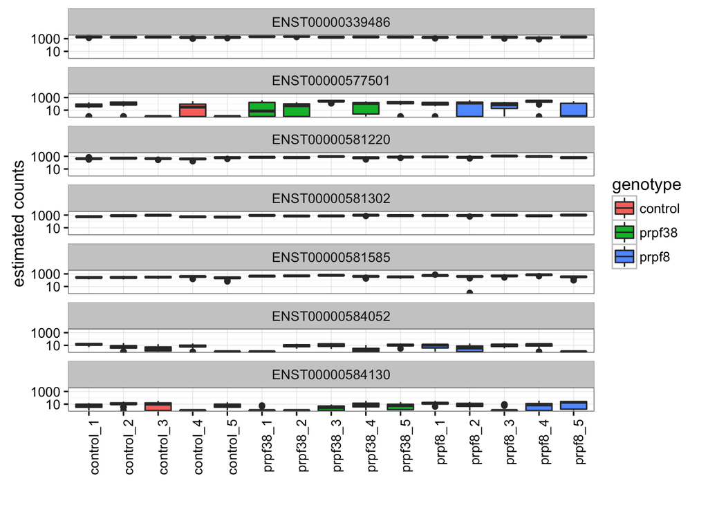

```r
> df = Map(function(x) {
+     get_bootstraps(so, x)
+ }, riok3_considered)
> df = do.call(rbind, df)
> ggplot(df, aes(sample, est_counts + 1, fill = genotype)) + geom_boxplot() +
+     facet_wrap(~target_id, ncol = 1) + theme_bw() + scale_y_log10() + theme(axis.text.x = element_text(angle = 90,
+     hjust = 1)) + ylab("estimated counts") + xlab("")
```

If we look at the alignments and log the counts, we can see that there might be a retained intron towards the 3’ end of the transcript:

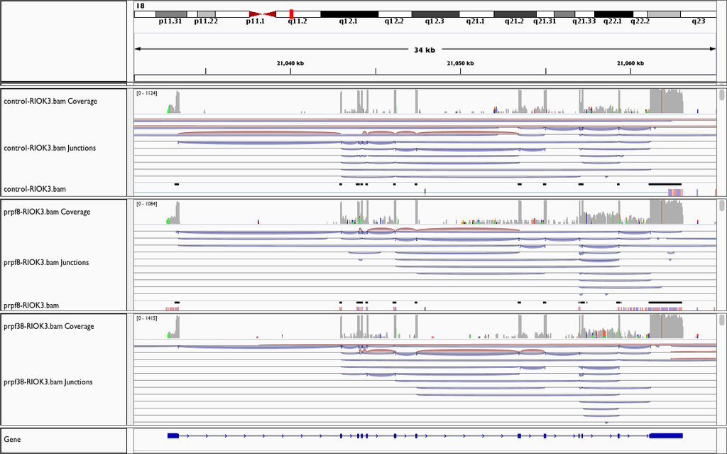

RIOK3-igv

But it isn’t the predominant isoform, it goes from 5 -> 20 counts or so if we mouse over the alignments. So there is some evidence that there is a retained intron event there if we visually inspect the alignments.

There is a pseudogene for RIOK3, RIOK3P1 but we don’t assign enough reads to affect the quantitation.

# Full tables of results

We’ll add an indicator to the tables that says whether or not a gene has reciprocal splicing changes before writing them out.

```r
> prpf8_tab = prpf8_tab %>% na.omit() %>% group_by(ens_gene) %>% mutate(reciprocal = (sum(b >
+     0 & qval < 0.05) > 0) & sum(b < 0 & qval < 0.05) > 0 & length(ens_gene) >
+     1) %>% as.data.frame()
> prpf38_tab = prpf38_tab %>% na.omit() %>% group_by(ens_gene) %>% mutate(reciprocal = (sum(b >
+     0 & qval < 0.05) > 0) & sum(b < 0 & qval < 0.05) > 0 & length(ens_gene) >
+     1) %>% as.data.frame()
> write.table(prpf8_tab, file = "control-vs-prpf8-sleuth.csv", quote = FALSE,
+     row.names = FALSE, col.names = TRUE, sep = ",")
> write.table(prpf38_tab, file = "control-vs-prpf38-sleuth.csv", quote = FALSE,
+     row.names = FALSE, col.names = TRUE, sep = ",")
```

control-vs-prpf8

control-vs-prpf38

# Write TPM matrix

```r
> tpm = so$obs_norm %>% dplyr::select(target_id, sample, tpm) %>% tidyr::spread(sample,
+     tpm)
> library(biomaRt)
> library(dplyr)
> human = useMart(biomart = "ENSEMBL_MART_ENSEMBL", dataset = "hsapiens_gene_ensembl",
+     host = "jul2015.archive.ensembl.org")
> symbols = getBM(attributes = c("ensembl_transcript_id", "external_gene_name",
+     "gene_biotype", "transcript_biotype"), mart = human)
> tpm = tpm %>% left_join(symbols, by = c(target_id = "ensembl_transcript_id"))
> write.table(tpm, file = "tpm.csv", quote = FALSE, col.names = TRUE, row.names = FALSE,
+     sep = ",")
```

TPM matrix

# Transcript MA plots

```r
> library(cowplot)
> sleuth_MA = function(results) {
+     results$DE = results$qval < 0.05
+     ggplot(results, aes(mean_obs, b, color = DE)) + geom_point(size = 0.5) +
+         guides(color = FALSE) + scale_color_manual(values = c("black", "red")) +
+         xlab("mean expression") + ylab(expression("<U+0392>")) + scale_x_log10()
+ }
```

## PRPF8

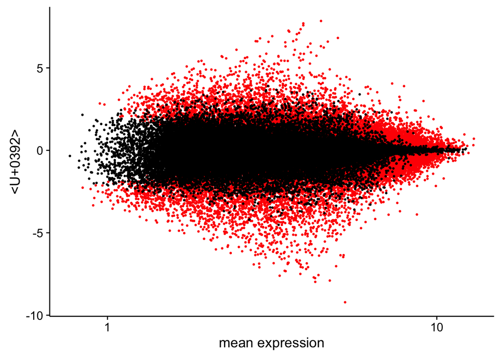

```r
> sleuth_MA(prpf8_tab)
```

## PRPF38

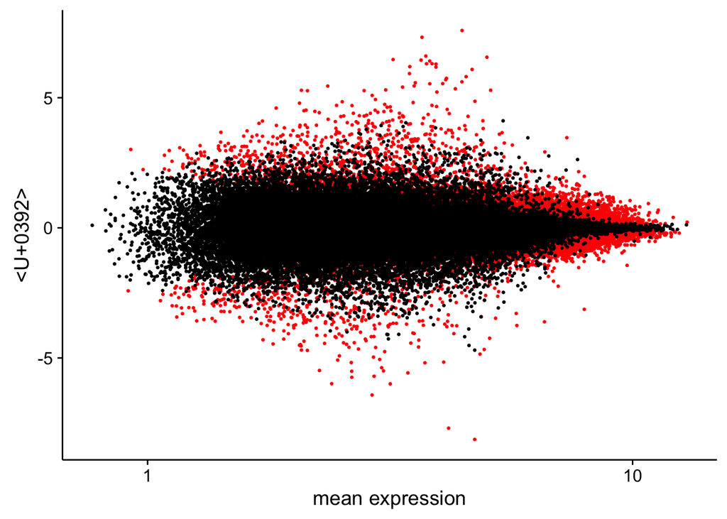

```r
> sleuth_MA(prpf38_tab)
```